# Churn Analysis For An Online Retail Store

# Distribution of annual income among customers.

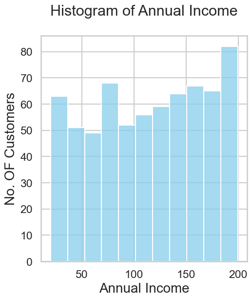

```python
plt.figure(figsize=(12, 6))


plt.subplot(1, 2, 1)
sns.histplot(data=df, x='Annual_Income', color='skyblue')
plt.title('Histogram of Annual Income')
plt.xlabel('Annual Income')
plt.ylabel('No. OF Customers')


plt.show()
```

# Gender & Age distribution of churned customers.

[figure not shown]

```python
plt.figure(figsize=(10, 6))

# Plotting the gender distribution by churn status
sns.countplot(df, x='Gender', hue='Target_Churn')
plt.title('Gender Distribution by Churn Status')
plt.xlabel('Gender')
plt.ylabel('Count')
plt.legend(title='Churn Status', labels=['Churned', 'Non-Churned'])

plt.show()
```

[figure not shown]

```python
plt.figure(figsize=(12, 6))
# Plotting the age distribution
plt.subplot(1, 2, 1)
sns.countplot(data=df, x='Age_Group', hue='Target_Churn')
plt.title('Age Distribution by Churn ')
plt.xlabel('Gender')
plt.ylabel('Count')
plt.legend(title='Churn ', labels=['Churned', 'Non-Churned'])
plt.show()
```

### Analysis on churn based on Satisfaction scores of customers

[figure not shown]

```python
plt.figure(figsize=(12, 6))


plt.subplot(1, 2, 1)
sns.countplot(data=df, x='Satisfaction_Score', hue='Target_Churn')
plt.title('Satisfaction_score Distribution by Churn ')
plt.xlabel('Score')
plt.ylabel('Count')
plt.legend(title='Churn ', labels=['Churned', 'Non-Churned'])
plt.show()
```

# Customer Behavior Analysis:

## Total spend distribution among customers.

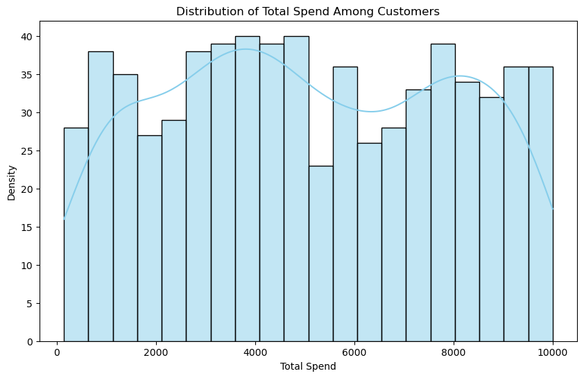

```python
# Create a figure
plt.figure(figsize=(10, 6))

# Plotting the distribution of total spend
sns.histplot(data=df, x='Total_Spend', bins=20, color='skyblue', kde=True)
plt.title('Distribution of Total Spend Among Customers')
plt.xlabel('Total Spend')
plt.ylabel('Density')

# Show plot
plt.show()
```

## Analysis of customer spending habits.

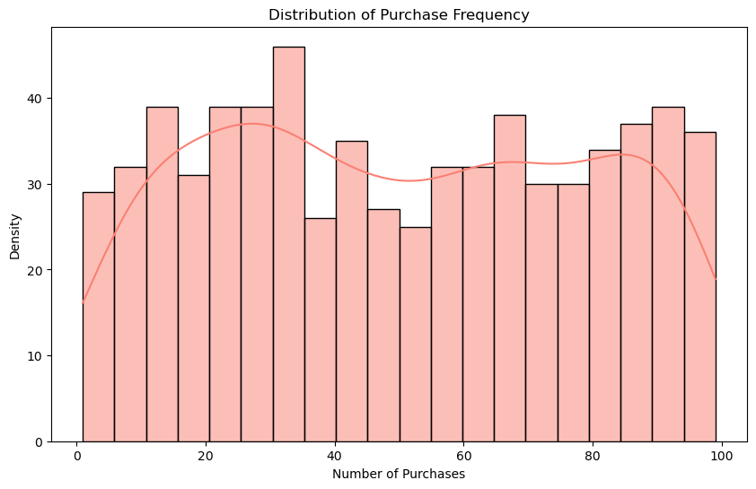

```python
# Assuming 'Num_of_Purchases' is the column representing the number of purchases
plt.figure(figsize=(10, 6))
sns.histplot(df['Num_of_Purchases'], bins=20, kde=True, color='salmon')
plt.title('Distribution of Purchase Frequency')
plt.xlabel('Number of Purchases')
plt.ylabel('Density')
plt.show()
```

```python
df.info()
```

```
<class 'pandas.core.frame.DataFrame'>
Index: 676 entries, 1 to 998
Data columns (total 16 columns):
 #   Column                      Non-Null Count  Dtype
---  ------                      --------------  -----
 0   Customer_ID                 676 non-null    int64
 1   Age                         676 non-null    int64
 2   Gender                      676 non-null    object
 3   Annual_Income               676 non-null    float64
 4   Total_Spend                 676 non-null    float64
 5   Years_as_Customer           676 non-null    int64
 6   Num_of_Purchases            676 non-null    int64
 7   Average_Transaction_Amount  676 non-null    float64
 8   Num_of_Returns              676 non-null    int64
 9   Num_of_Support_Contacts     676 non-null    int64
 10  Satisfaction_Score          676 non-null    int64
 11  Last_Purchase_Days_Ago      676 non-null    int64
 12  Email_Opt_In                676 non-null    bool
 13  Promotion_Response          676 non-null    object
 14  Target_Churn                676 non-null    bool
 15  Age_Group                   676 non-null    category
dtypes: bool(2), category(1), float64(3), int64(8), object(2)
memory usage: 76.1+ KB
```

## Relationship between total spend and annual income.

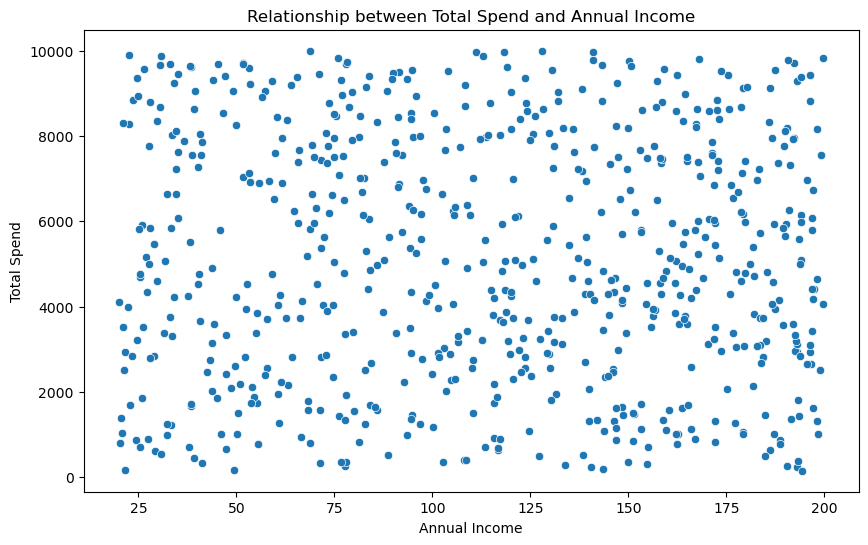

```python
plt.figure(figsize=(10, 6))
sns.scatterplot(df, x='Annual_Income', y='Total_Spend', palette=['blue', 'red'])
plt.title('Relationship between Total Spend and Annual Income')
plt.xlabel('Annual Income')
plt.ylabel('Total Spend')

plt.show()
```

```
Correlation Coefficient: -0.024694802382669672
--------------------------------------------------

--------------------------------------------------
```

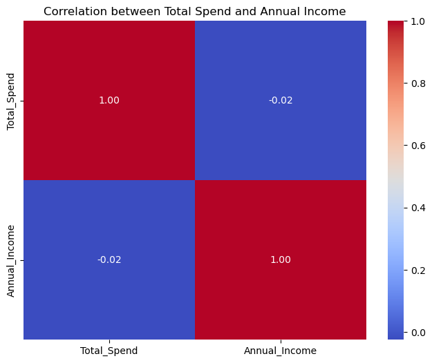

```python
# Calculating correlation coefficient

correlation_coefficient = df['Total_Spend'].corr(df['Annual_Income'])
print("Correlation Coefficient:", correlation_coefficient)
print('-'*50)
print(' '*50)
print('-'*50)
# Calculate the correlation matrix
corr_matrix = df[['Total_Spend', 'Annual_Income']].corr()
plt.figure(figsize=(8, 6))
sns.heatmap(corr_matrix, annot=True, cmap='coolwarm', fmt=".2f")
plt.title('Correlation between Total Spend and Annual Income')
plt.show()
```

```python
dummy = pd.get_dummies(df)
```

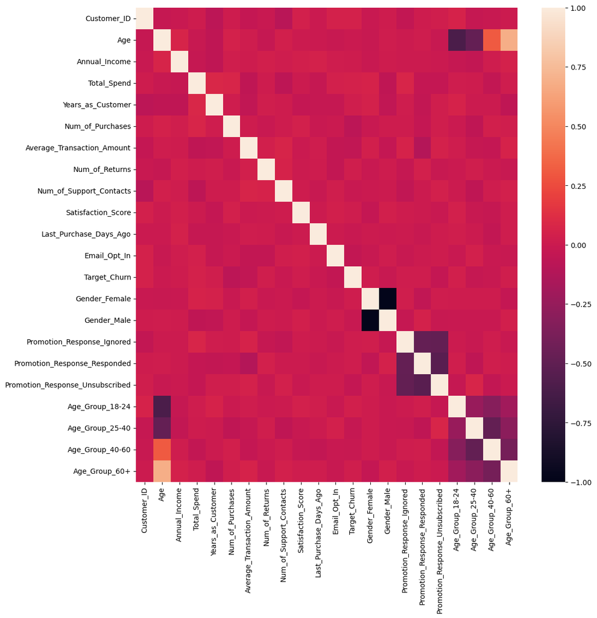

```python
plt.figure(figsize = (12,12))
sns.heatmap(dummy.corr())
```

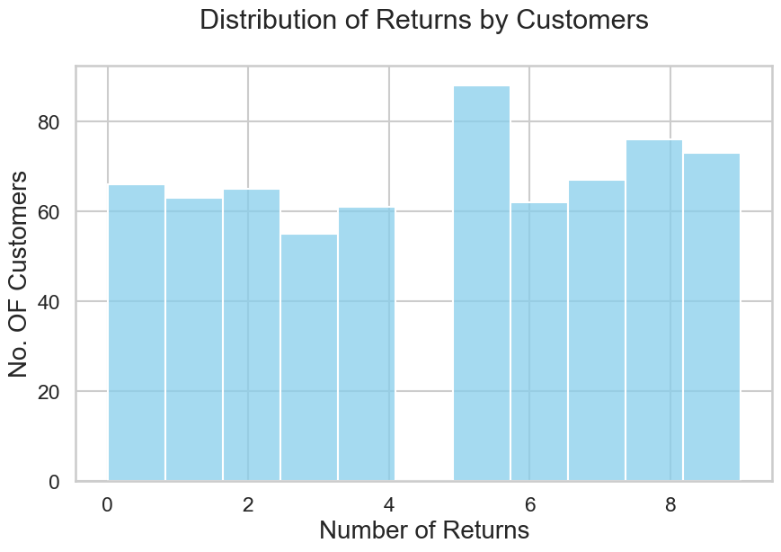

```python
plt.figure(figsize=(10, 6))

# Plotting the distribution of returns
sns.histplot(df, x='Num_of_Returns', color='skyblue')
plt.title('Distribution of Returns by Customers')
plt.xlabel('Number of Returns')
plt.ylabel('No. OF Customers')


plt.show()
```

# Customer Engagement and Support Analysis:

## Number of years each customer has been with the store.

```python
df.Years_as_Customer.value_counts()
```

```
Years_as_Customer
18    45
4     45
13    44
9     44
1     42
7     40
19    37
12    37
6     37
2     36
3     36
10    34
5     31
16    31
14    31
8     30
15    29
11    26
17    21
Name: count, dtype: int64
```

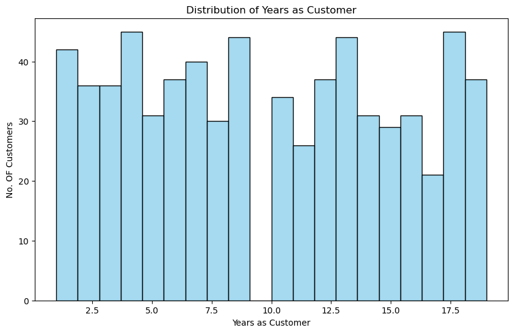

```python
plt.figure(figsize=(10, 6))

# Plotting the distribution of years as customer
sns.histplot(data=df, x='Years_as_Customer', bins=20, color='skyblue', kde=False)
plt.title('Distribution of Years as Customer')
plt.xlabel('Years as Customer')
plt.ylabel('No. OF Customers')


plt.show()
```

## Number of support contacts made by customers

```python
df.Num_of_Support_Contacts.value_counts()
```

```
Num_of_Support_Contacts
1    146
3    137
0    136
2    135
4    122
Name: count, dtype: int64
```

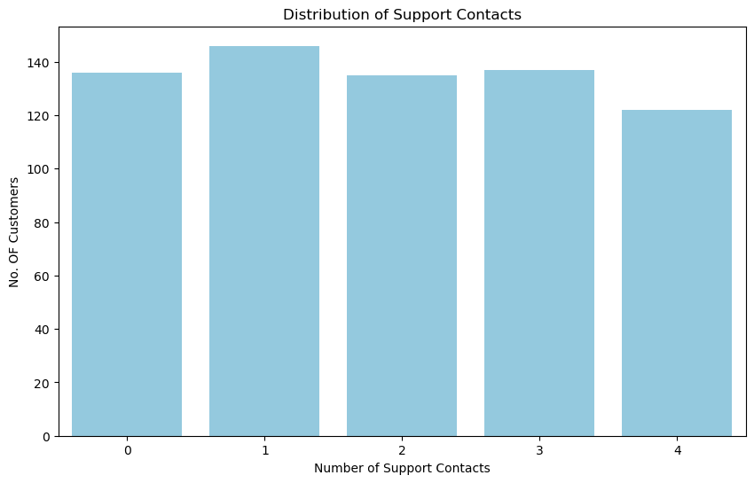

```python
plt.figure(figsize=(10, 6))

# Plotting the distribution of support contacts using a bar plot
sns.countplot(data=df, x='Num_of_Support_Contacts', color='skyblue')
plt.title('Distribution of Support Contacts')
plt.xlabel('Number of Support Contacts')
plt.ylabel('No. OF Customers')


plt.show()
```

## Email opt-in among customers.

```python
df.Email_Opt_In.value_counts()
```

```
Email_Opt_In
True     350
False    326
Name: count, dtype: int64
```

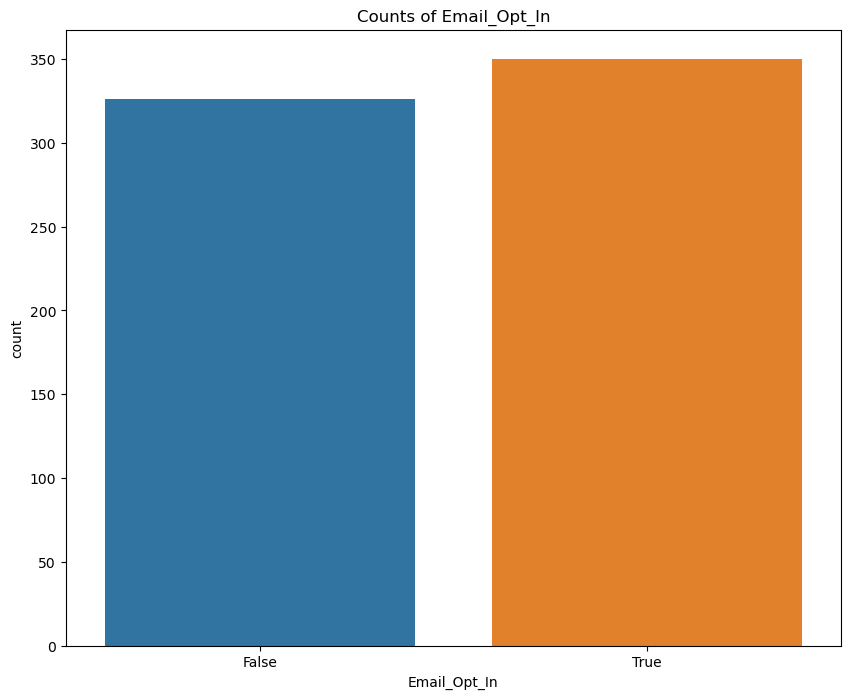

```python
plt.figure(figsize=(10,8))
sns.countplot(data = df, x='Email_Opt_In')
plt.title('Counts of Email_Opt_In')
plt.show()
```

Approximately 350 customers have opted in to receive emails, while 326 customers have declined, selecting false as their preference.

## Response to promotional campaigns.

```python
#value count of the Promotion_Response
response_counts= df.Promotion_Response.value_counts()

response_counts
```

```
Promotion_Response
Unsubscribed    236
Responded       234
Ignored         206
Name: count, dtype: int64
```

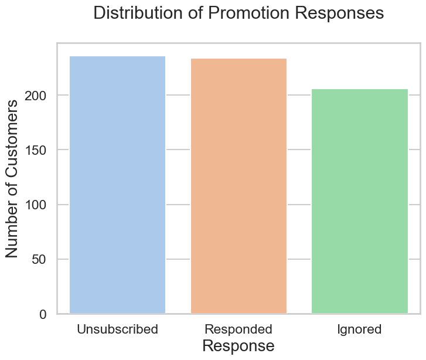

```python
response_counts = df['Promotion_Response'].value_counts()

plt.figure(figsize=(8, 6))

# Plotting the distribution of promotion responses using a bar plot
sns.barplot(x=response_counts.index, y=response_counts.values, palette='pastel')
plt.title('Distribution of Promotion Responses')
plt.xlabel('Response')
plt.ylabel('Number of Customers')


# Show plot
plt.show()
```

The outcomes of the promotion responses are as follows: 236 customers chose to unsubscribe, indicating they didn't want any promotional updates or so.

On the other hand, 234 customers responded positively to the promotion, showing interest in the offer or message conveyed.

However, 206 customers chose to ignore the promotion entirely, neither responding positively nor opting out.

Understanding these response outcomes is essential for refining promotional strategies, tailoring messages to better resonate with the target audience, and optimizing the overall effectiveness of marketing campaigns.

# Customer Satisfaction and Churn Analysis

## Distribution of satisfaction scores among age groups and Gender

```python
#Customer rating
Satisfaction = df.Satisfaction_Score.value_counts()
Satisfaction
```

```
Satisfaction_Score
3    150
4    143
1    135
5    128
2    120
Name: count, dtype: int64
```

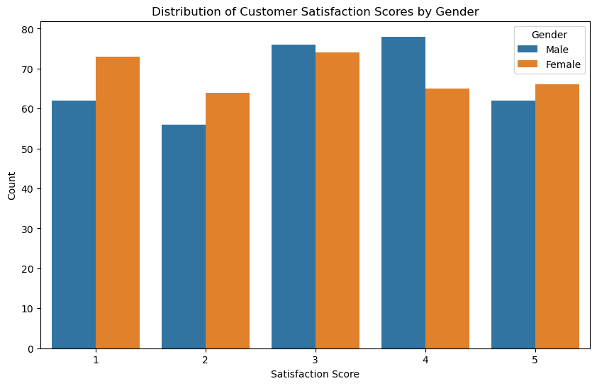

```python
satisfaction = df['Satisfaction_Score'].value_counts()
plt.figure(figsize=(10, 6))
sns.countplot(data=df, x='Satisfaction_Score', hue='Gender')
plt.title('Distribution of Customer Satisfaction Scores by Gender')
plt.xlabel('Satisfaction Score')
plt.ylabel('Count')
plt.show()
```

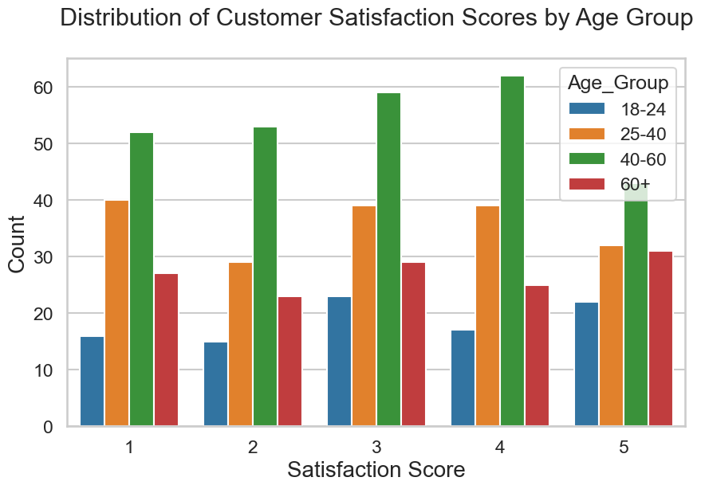

```python
# Creating a countplot to visualize the distribution of customer satisfaction scores with respect to age groups
plt.figure(figsize=(10, 6))
sns.countplot(data=df, x='Satisfaction_Score', hue='Age_Group')
plt.title('Distribution of Customer Satisfaction Scores by Age Group')
plt.xlabel('Satisfaction Score')
plt.ylabel('Count')
plt.show()
```

```python
df.Target_Churn.value_counts()
```

```
Target_Churn
True     348
False    328
Name: count, dtype: int64
```

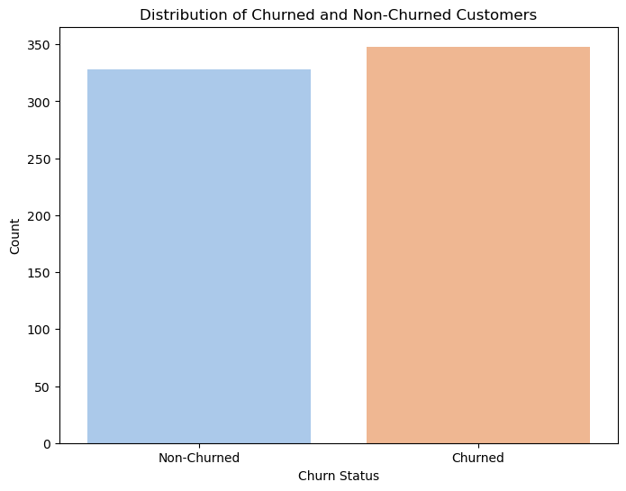

```python
plt.figure(figsize=(8, 6))
sns.countplot(data=df, x='Target_Churn', palette='pastel')
plt.title('Distribution of Churned and Non-Churned Customers')
plt.xlabel('Churn Status')
plt.ylabel('Count')
plt.xticks(ticks=[0, 1], labels=['Non-Churned', 'Churned'])  # Set x-axis labels
plt.show()
```

**The data indicates that the number of customers who churned from the service or product had the highest count, followed by those who remained non-churned. Understanding churn rates is vital for businesses to assess customer satisfaction, identify potential pain points, and implement retention strategies.**

```python
a1 = df.loc[df['Target_Churn']==0]
a2 = df.loc[df['Target_Churn']==0]
```

```python
def uniplot(df, col, title, hue =None):

    sns.set_style('whitegrid')
    sns.set_context('talk')
    plt.rcParams["axes.labelsize"] = 20
    plt.rcParams['axes.titlesize'] = 22
    plt.rcParams['axes.titlepad'] = 30

    temp = pd.Series(data = hue)
    fig, ax = plt.subplots()
    width= len(df[col].unique()) +7+4*len(temp.unique())
    fig.set_size_inches (width, 8)
    plt.xticks (rotation=45)
    plt.yscale('log')
    plt.title(title)
    ax = sns.countplot(data = df, x= col, order=df[col].value_counts().index, hue=hue, palette='bright')

plt.show()
```

[figure not shown]

```python
uniplot(a2, col='Age_Group', title='Distribution of Gender for Churned Customers', hue="Gender")
```

[figure not shown]

```python
uniplot(a2, col='Age_Group', title='Distribution of Gender for Churned Customers', hue="Email_Opt_In")
```

```python
df
```

|  | Customer_ID | Age | Gender | Annual_Income | Total_Spend | Years_as_Customer | Num_of_Purchases | Average_Transaction_Amount | Num_of_Returns | Num_of_Support_Contacts | Satisfaction_Score | Last_Purchase_Days_Ago | Email_Opt_In | Promotion_Response | Target_Churn | Age_Group |
| --- | --- | --- | --- | --- | --- | --- | --- | --- | --- | --- | --- | --- | --- | --- | --- | --- |
| 1 | 2 | 65 | Male | 79.51 | 9025.47 | 13 | 77 | 22.90 | 2 | 2 | 3 | 227 | False | Responded | False | 60+ |
| 2 | 3 | 18 | Male | 29.19 | 618.83 | 13 | 71 | 50.53 | 5 | 2 | 2 | 283 | False | Responded | True | 18-24 |
| 5 | 6 | 57 | Male | 190.43 | 255.19 | 19 | 85 | 417.78 | 5 | 1 | 4 | 130 | False | Unsubscribed | False | 40-60 |
| 6 | 7 | 27 | Male | 172.13 | 3512.55 | 3 | 77 | 316.18 | 0 | 3 | 1 | 61 | True | Unsubscribed | False | 25-40 |
| 10 | 11 | 54 | Male | 138.90 | 4283.84 | 15 | 33 | 96.55 | 9 | 1 | 2 | 92 | True | Responded | False | 40-60 |
| ... | ... | ... | ... | ... | ... | ... | ... | ... | ... | ... | ... | ... | ... | ... | ... | ... |
| 992 | 993 | 50 | Male | 167.73 | 7380.55 | 4 | 10 | 46.12 | 1 | 2 | 2 | 173 | True | Ignored | True | 40-60 |
| 995 | 996 | 54 | Male | 143.72 | 1089.09 | 2 | 29 | 77.75 | 0 | 3 | 2 | 88 | True | Ignored | False | 40-60 |
| 996 | 997 | 19 | Male | 164.19 | 3700.24 | 9 | 90 | 34.45 | 6 | 4 | 4 | 352 | False | Responded | True | 18-24 |
| 997 | 998 | 47 | Female | 113.31 | 705.85 | 17 | 69 | 187.37 | 7 | 3 | 1 | 172 | True | Unsubscribed | False | 40-60 |
| 998 | 999 | 23 | Male | 72.98 | 3891.60 | 7 | 31 | 483.80 | 1 | 2 | 5 | 55 | False | Responded | True | 18-24 |

676 rows × 16 columns

[figure not shown]

```python
uniplot(a2, col = 'Satisfaction_Score' , title='Distribution of Gender for Churned Customers', hue="Gender")
```

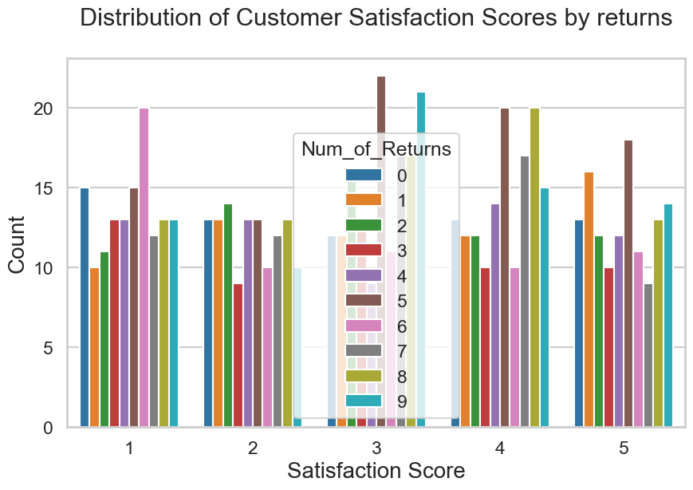

```python
satisfaction = df['Satisfaction_Score'].value_counts()
plt.figure(figsize=(10, 6))
sns.countplot(data=df, x='Satisfaction_Score', hue='Num_of_Returns')
plt.title('Distribution of Customer Satisfaction Scores by returns')
plt.xlabel('Satisfaction Score')
plt.ylabel('Count')
plt.show()
```

# Conclusion

1) Based on the age groups column i have made , it shows that higher percentage of customers are in their age of 40-60(i.e, 39.8%). This age group is the one with the highest email opt-ins. And also Female customers are higher than the males.

2) Highest number of returns made together by individuals are 5 and their satisfaction score being average of just 3 out of 5

3) Number of churned customers are higher than non-churned customers

4) As the ratings from the customers seem to be not high , that directly meaning that they wouldn't be getting a satisfactory product. This would normally lead to churns in customers & as it shows churns are more than non-churns